# 算法训练营Day 27

Author

Siru Wu

Published

March 1, 2026

今天是**贪心算法（Greedy Algorithm）**。

## [455.分发饼干](https://leetcode.cn/problems/assign-cookies/description/)

> 假设你是一位很棒的家长，想要给你的孩子们一些小饼干。但是，每个孩子最多只能给一块饼干。

> 对每个孩子 i，都有一个胃口值 g[i]，这是能让孩子们满足胃口的饼干的最小尺寸；并且每块饼干 j，都有一个尺寸 s[j] 。如果 s[j] >= g[i]，我们可以将这个饼干 j 分配给孩子 i ，这个孩子会得到满足。你的目标是满足尽可能多的孩子，并输出这个最大数值。

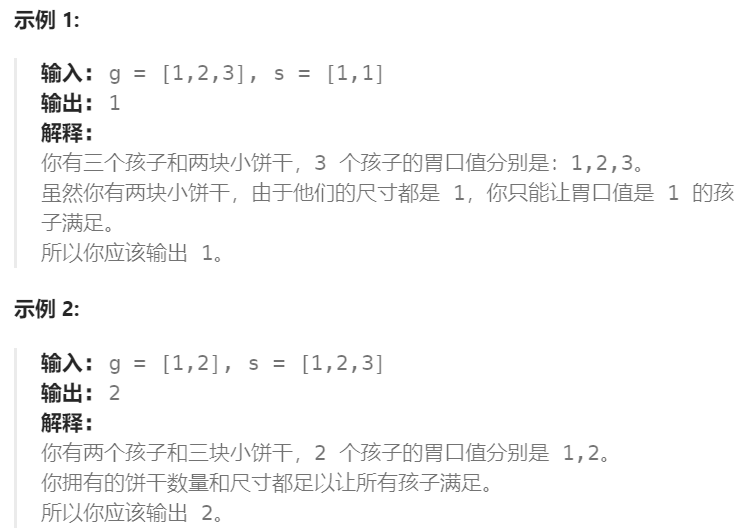

### 贪心 大饼干优先

```python
class Solution:
    def findContentChildren(self, g: List[int], s: List[int]) -> int:
        g.sort()
        s.sort()
        index = len(s) - 1 # index是s的，用来控制最大的饼干
        result = 0
        for i in range(len(g) - 1, -1, -1): # range是左闭右开，现在我们从list末尾从后往前数所以len(g)要减1
          if index >= 0 and s[index] >= g[i]: # g[i]是用来找哪个是胃口最大的孩子
            resule += 1
            index -= 1
        return result
```

### 贪心 小饼干优先

```python
class Solution:
    def findContentChildren(self, g, s):
        g.sort()  # 将孩子的贪心因子排序
        s.sort()  # 将饼干的尺寸排序
        index = 0
        for i in range(len(s)):  # 遍历饼干
            if index < len(g) and g[index] <= s[i]:  # 如果当前孩子的贪心因子小于等于当前饼干尺寸
                index += 1  # 满足一个孩子，指向下一个孩子
        return index  # 返回满足的孩子数目
```

## [376. 摆动序列](https://leetcode.cn/problems/wiggle-subsequence/description/)

> 如果连续数字之间的差严格地在正数和负数之间交替，则数字序列称为 摆动序列 。第一个差（如果存在的话）可能是正数或负数。仅有一个元素或者含两个不等元素的序列也视作摆动序列。

> 例如， [1, 7, 4, 9, 2, 5] 是一个 摆动序列 ，因为差值 (6, -3, 5, -7, 3) 是正负交替出现的。

> 相反，[1, 4, 7, 2, 5] 和 [1, 7, 4, 5, 5] 不是摆动序列，第一个序列是因为它的前两个差值都是正数，第二个序列是因为它的最后一个差值为零。 子序列 可以通过从原始序列中删除一些（也可以不删除）元素来获得，剩下的元素保持其原始顺序。

> 给你一个整数数组 nums ，返回 nums 中作为 摆动序列 的 最长子序列的长度 。

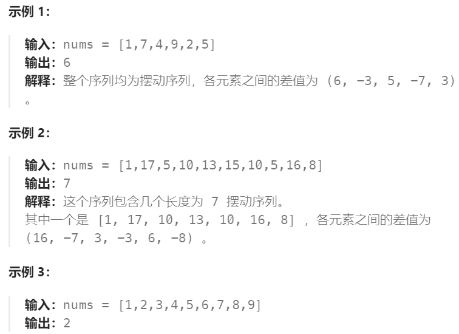

```python
class Solution:
    def wiggleMaxLength(self, nums: List[int]) -> int:
        if len(nums) <= 1:
            return len(nums)

        prediff, curdiff, result = 0, 0, 1
        for i in range(len(nums) - 1):
            curdiff = nums[i + 1] - nums[i]
            if prediff * curdiff <= 0 and curdiff != 0:
            # 版本二：if (preDiff <= 0 and curDiff > 0) or (preDiff >= 0 and curDiff < 0):
                result += 1
                prediff = curdiff
        return result
```

## [53. 最大子序和](https://leetcode.cn/problems/maximum-subarray/description/)

> 给你一个整数数组 nums ，请你找出一个具有最大和的连续子数组（子数组最少包含一个元素），返回其最大和。

> 子数组是数组中的一个连续部分。

> **示例 1：**
> - 输入：nums = [-2,1,-3,4,-1,2,1,-5,4]
> - 输出：6
> - 解释：连续子数组 [4,-1,2,1] 的和最大，为 6 。

> **示例 2：**
> - 输入：nums = [1]
> - 输出：1

> **示例 3：**
> - 输入：nums = [5,4,-1,7,8]
> - 输出：23

### 暴力法（但是提交会超出时间限制）

```python
class Solution:
    def maxSubArray(self, nums: List[int]) -> int:
        max_sum = float('-inf')
        count = 0
        for i in range(len(nums)):
            count = 0
            for j in range(i, len(nums)):
                count += nums[j]
                max_sum = max(count, max_sum)
        return max_sum
```

### 贪心算法

```python
class Solution:
    def maxSubArray(self, nums):
        result = float('-inf')  # 初始化结果为负无穷大
        count = 0
        for i in range(len(nums)):
            count += nums[i]
            if count > result:  # 取区间累计的最大值（相当于不断确定最大子序终止位置）
                result = count
            if count <= 0:  # 相当于重置最大子序起始位置，因为遇到负数一定是拉低总和
                count = 0
        return result
```